# ML_project_TiU-7

# Part 2: Predictive Modeling

## Model initializing

```python
# This is all we have as a data pipeline:

class OutlierRemover(BaseEstimator, TransformerMixin):
    def __init__(self, contamination=0.05, random_state=42):
        self.contamination = contamination
        self.random_state = random_state
        self.isolation_forest = None

    def fit(self, X, y=None):
        self.isolation_forest = IsolationForest(
            contamination=self.contamination, random_state=self.random_state
        )
        self.isolation_forest.fit(X)
        return self

    def transform(self, X, y=None):
        outliers = self.isolation_forest.predict(X)  # -1 for outliers, 1 for inliers
        return X[outliers == 1]

# Example usage
outlier_remover = OutlierRemover(contamination=0.05)
data_cleaned = outlier_remover.fit_transform(data)
data=data_cleaned.copy()
```

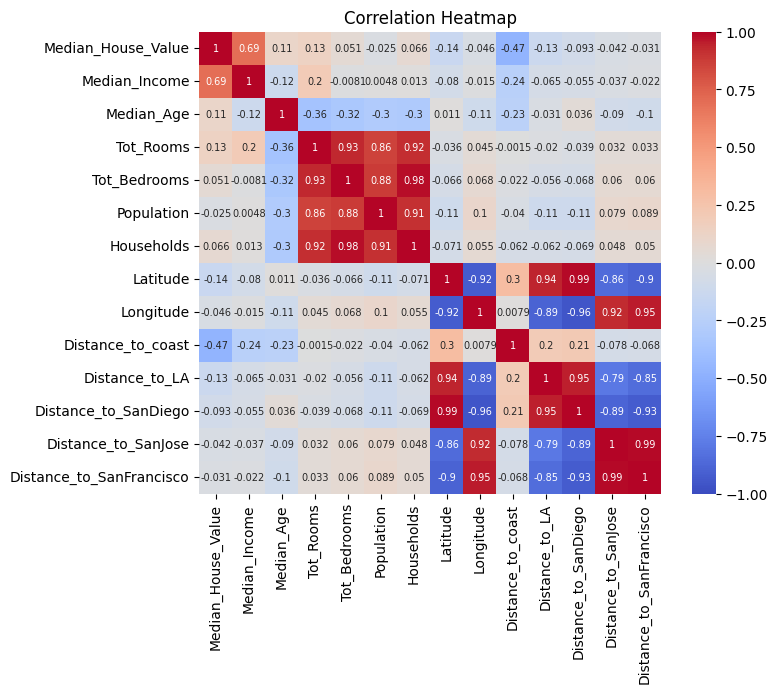

```python
corr_matrix = data.corr()

plt.figure(figsize=(8, 6))
sns.heatmap(corr_matrix, annot=True, cmap='coolwarm',annot_kws={'size': 7}, vmin=-1, vmax=1, square=True)
plt.title("Correlation Heatmap")
plt.show()
```

We want to analyze our dataset and make predictions using three models:

1. Linear Model (including different variations); Reason for this choice is that this is the most used and the easiest model. In addition, we are in the social science / policy proposal setting, where linear regression are used the most.
2. Decision Tree Regressor; Reason: Just why not - it is interesting to check its performance on the dataset like this one; In addition, it is a simple algorithm that does not have any problems because of the multicollinearity.
3. XGBoost; Reason: this model is one of the most powerful

However, a problem arises because we are choosing a linear model. Take a look at our data.

There is high correlation between several variables and therefore there is a possible multicolinearity.

If from one side, it is not problematic for Ensemble or Tree models, it is a great issue for the linear model.

It is problematic since with multicollinearity

1. Our beta coefficients can be unstable;
2. Our gradient descent algorithm which is incorporated into linear models could have issues with finding a min and therefore finding optimal betas.

Therefore, we need to check for multicolinearity.

1. If there is no multicollinearity - the best strategy then would be leaving all variables;
2. If there is one - we need to drop some variables.

The problem of this way is that we can loose some important information for Trees and XGBoost while gaining only in predictive power of linear model.

So now we need to work with feature selection and explore for milticollinearity.

We see that there are two blocks of Highly-correlated data.

1. On neighborhood parameters (Number of Rooms, Bedrooms, Population, Households). It is obvious why they are correlated. More people is almost the same with more household. More people $\to$ more rooms needed (and bedrooms as well).
2. Location parameters. Mathematically they are multicolinear. We have distances from different cities + coordinates. We are almost sure that they were obtained as just taking distance function, so all distances are coming from coordinates. Aditionally, if we have 3 distances from 3 different point in space, we can obtain its coordinate and therefore get 4th coordinate.

However, there is a problem.

1. With neighborhood parameters, omitting variables can lead to some problems with the predictive power of non-linear models.
2. With coordinates, omitting one variable (let's say distance to SF) can lead to a lot of problems with predictive power. The reason for this is that housing prices are usually higher if house is close to the city centre + housing prices in cities are higher + housing prices vary across cities. So here we can lost a lot of information.

VIF Test can help us to explore whether there is a multicollinearity.

```python
# Example dataset
X = data[['Distance_to_coast',
               'Distance_to_LA' ,
           'Distance_to_SanJose',
          'Distance_to_SanFrancisco',
          'Distance_to_SanDiego'
          ]].copy()

# Add a constant for intercept
X_cs = add_constant(X)

# Calculate VIF for each feature
vif_data = pd.DataFrame()
vif_data["Feature"] = X_cs.columns
vif_data["VIF"] = [variance_inflation_factor(X_cs.values, i) for i in range(X_cs.shape[1])]

print(vif_data)
```

```
                    Feature         VIF
0                     const  230.131667
1         Distance_to_coast    1.704420
2            Distance_to_LA   11.790759
3       Distance_to_SanJose  102.984645
4  Distance_to_SanFrancisco  194.417884
5      Distance_to_SanDiego   46.506521
```

```python
X = data[['Distance_to_coast',
               'Distance_to_LA' ,
           'Distance_to_SanJose',
          'Distance_to_SanDiego'
          ]].copy()

# Add a constant for intercept
X_cs = add_constant(X)

# Calculate VIF for each feature
vif_data = pd.DataFrame()
vif_data["Feature"] = X_cs.columns
vif_data["VIF"] = [variance_inflation_factor(X_cs.values, i) for i in range(X_cs.shape[1])]

print(vif_data)
```

```
                Feature        VIF
0                 const  92.417104
1     Distance_to_coast   1.156470
2        Distance_to_LA  11.667028
3   Distance_to_SanJose  10.301033
4  Distance_to_SanDiego  28.593551
```

```python
X = data[['Distance_to_coast',
               'Distance_to_LA' ,
           'Distance_to_SanJose',
          ]].copy()

# Add a constant for intercept
X_cs = add_constant(X)

# Calculate VIF for each feature
vif_data = pd.DataFrame()
vif_data["Feature"] = X_cs.columns
vif_data["VIF"] = [variance_inflation_factor(X_cs.values, i) for i in range(X_cs.shape[1])]

print(vif_data)
```

```
               Feature        VIF
0                const  24.984709
1    Distance_to_coast   1.046817
2       Distance_to_LA   3.720955
3  Distance_to_SanJose   3.632448
```

VIF analysis shows that there is multicollinearity indeed. However, we tested this problem later with analysis later.